# Data Processing Vignette

2022-10-27

### Setting up

Make sure that gnomeR & cbioportalR packages are installed & loaded

```c
install.packages("cbioportalR")
library(cbioportalR)
install.packages("gnomeR")
library(gnomeR)
```

For details on how to connect and access cbioportalR, you can use the link https://github.com/karissawhiting/cbioportalR or follow the steps below

For every new R session, you need to set your database URL. The set_cbioportal_db() function will set an environmental variable for your session that tells the package which database to point to for all API calls. You can set it to point to the public database with db = ‘www.cbioportal.org’ or db = ‘public’

```r
set_cbioportal_db(db = "public")
```

```
#> ✔ You are successfully connected!
#> ✔ base_url for this R session is now set to "www.cbioportal.org/api"
```

You are now set up for the remainder of your session! API calls depend on your internet connection and possibly a VPN connection so you can use the following to check your connection at any time throughout your session:

```r
test_cbioportal_db()
```

```
#> ✔ You are successfully connected!
```

This vignette will walk you through how to import data for a particular study from cbioportal and process it using some gnomeR functions.

Once connected to cbioportal, you can get the list of studies (limited to 5 here) by using -

```r
available_studies() %>% head(n = 5)
```

```
#> # A tibble: 5 × 13
#>   studyId    name  descr…¹ publi…² groups status impor…³ allSa…⁴ readP…⁵ cance…⁶
#>   <chr>      <chr> <chr>   <lgl>   <chr>   <int> <chr>     <int> <lgl>   <chr>
#> 1 acc_tcga   Adre… "TCGA … TRUE    PUBLIC      0 2022-0…      92 TRUE    acc
#> 2 bcc_unige… Basa… "Whole… TRUE    PUBLIC      0 2022-0…     293 TRUE    bcc
#> 3 ampca_bcm… Ampu… "Exome… TRUE    PUBLIC      0 2022-0…     160 TRUE    ampca
#> 4 blca_dfar… Blad… "Whole… TRUE    PUBLIC      0 2022-0…      50 TRUE    blca
#> 5 blca_mskc… Blad… "Compr… TRUE    PUBLIC      0 2022-0…      97 TRUE    blca
#> # … with 3 more variables: referenceGenome <chr>, pmid <chr>, citation <chr>,
#> #   and abbreviated variable names ¹description, ²publicStudy, ³importDate,
#> #   ⁴allSampleCount, ⁵readPermission, ⁶cancerTypeId
```

To get information on a particular study (eg - acbc_mskcc_2015) -

```r
get_study_info("acbc_mskcc_2015") %>% t()
```

```
#>                             [,1]
#> name                        "Adenoid Cystic Carcinoma of the Breast (MSK, J Pathol. 2015)"
#> description                 "Whole exome sequencing of 12 breast AdCCs."
#> publicStudy                 "TRUE"
#> pmid                        "26095796"
#> citation                    "Martelotto et al. J Pathol 2015"
#> groups                      "ACYC;PUBLIC"
#> status                      "0"
#> importDate                  "2022-10-26 08:25:55"
#> allSampleCount              "12"
#> sequencedSampleCount        "12"
#> cnaSampleCount              "12"
#> mrnaRnaSeqSampleCount       "0"
#> mrnaRnaSeqV2SampleCount     "0"
#> mrnaMicroarraySampleCount   "0"
#> miRnaSampleCount            "0"
#> methylationHm27SampleCount  "0"
#> rppaSampleCount             "0"
#> massSpectrometrySampleCount "0"
#> completeSampleCount         "0"
#> readPermission              "TRUE"
#> studyId                     "acbc_mskcc_2015"
#> cancerTypeId                "acbc"
#> cancerType.name             "Adenoid Cystic Breast Cancer"
#> cancerType.dedicatedColor   "HotPink"
#> cancerType.shortName        "ACBC"
#> cancerType.parent           "brca"
#> cancerType.cancerTypeId     "acbc"
#> referenceGenome             "hg19"
```

### Importing data in R

To get data from a specific study -

```r
df <- get_genetics_by_study(study_id = "acbc_mskcc_2015")
```

```
#> ℹ Returning all data for the "acbc_mskcc_2015_mutations" molecular profile in the "acbc_mskcc_2015" study
#> ℹ Returning all data for the "acbc_mskcc_2015_cna" molecular profile in the "acbc_mskcc_2015" study
#> ℹ Returning all data for the "acbc_mskcc_2015_structural_variants" molecular profile in the "acbc_mskcc_2015" study
```

It creates a list of all the available dataframes for the study. For instance here, the study has 3 - one for each of Mutation, CNA and Structural Variants.

Depending on the study, the number of variables in a particular dataframe might be different. Here, the mutations data has 31 variables.

You can create one dataset each for the 3 types using-

```r
study_mutation<- as.data.frame(df$mutation)

study_sv<- as.data.frame(df$structural_variant)

study_cna<- as.data.frame(df$cna)
```

#### Mutation Data

If you download the raw data from cbioportal and compare with the study_mutation data imported above, you might notice some differences in the variables. For instance

```
* Tumor_Sample_Barcode is called sampleId in the imported data
* The Hugo_symbol is embedded within the keyword variable
* Variant_Classification is called mutationType
* HGVSp_Short is called proteinChange
* Chromosome is called 'chr'
```

Some of the other variables are named differently as well in the raw data and the imported data but those differences are more intuitive to map the variables.

#### CNA data formats

CNA data can be received in a long or wide format.

```
* Long format -  When each row contains data on a gene for a patient as shown below.
  Data is at the patient gene level.
```

```r
study_cna %>% head(n = 3)
```

```
#>   hugoGeneSymbol entrezGeneId                uniqueSampleKey
#> 1       SLC25A25       114789 QWRDQzVUOmFjYmNfbXNrY2NfMjAxNQ
#> 2          WDR38       401551 QWRDQzVUOmFjYmNfbXNrY2NfMjAxNQ
#> 3            AK1          203 QWRDQzVUOmFjYmNfbXNrY2NfMjAxNQ
#>                 uniquePatientKey  molecularProfileId sampleId patientId
#> 1 QWRDQzVUOmFjYmNfbXNrY2NfMjAxNQ acbc_mskcc_2015_cna   AdCC5T    AdCC5T
#> 2 QWRDQzVUOmFjYmNfbXNrY2NfMjAxNQ acbc_mskcc_2015_cna   AdCC5T    AdCC5T
#> 3 QWRDQzVUOmFjYmNfbXNrY2NfMjAxNQ acbc_mskcc_2015_cna   AdCC5T    AdCC5T
#>           studyId alteration
#> 1 acbc_mskcc_2015         -2
#> 2 acbc_mskcc_2015         -2
#> 3 acbc_mskcc_2015         -2
```

```
* Wide format - When each column contains data for a unique patient.
  For example - Patient A's data is in the 1st column and Patient B's data is in the 2nd column.
```

### Some useful functions to process the data

#### create_gene_binary() function

You can use the create_gene_binary() function to

Transpose the mutations data - By default, the mutations data has one or more rows for each patient. Each row is data on a gene. The data can be transposed to create one row per patient with each column for a gene. The cell value in the transposed data would flag whether a particular gene has mutation for that patient.

```r
mut.only <- create_gene_binary(mutation = study_mutation)
```

```
#> ℹ `samples` argument is `NULL`. We will infer your cohort inclusion and resulting data frame will include all samples with at least one alteration in mutation, fusion or cna data frames
```

The other datasets can be transposed similarly.

For the fusion data - if the gene is part of the IMPACT dataset, then there will be a column for it in the transposed data.

You can also create one wide data with combined data from all the different datasets after transposing them. Here a dataset called all3 is created for ten samples

```r
samples <- unique(study_mutation$sampleId)[1:10]
all3 <- create_gene_binary(
    samples = samples,
    mutation = study_mutation,
    cna = study_cna, fusion = study_sv,
    mut_type = "somatic_only", snp_only = FALSE,
    specify_panel = "no"
)
```

Notes on some arguments:

```
* The arguments mutation, fusion and cna can be used to specify the datasets you want to transpose.
* If you are only interested in data for some sample IDs, you can mention those in the argument samples.
```

#### summarize_by_gene() function

You may notice some columns being repeated in the data when you create a combined dataset for the transposed datasets for Mutations, CNA and Fusion. To keep only the unique columns for genes, you can use the summarize_by_gene() function as shown below

```r
 sum_all3 <- summarize_by_gene(all3)
```

The data all3 has 1855 columns. And the data sum_all3 has 1836 variables as it only keeps the unique columns across the datasets.

#### tbl_genomic() function

The function can be used to summarize data by gene. You can summarize data from one or more of the data types. The gene_binary argument expects the binary matrix data as generated by the create_gene_binary function. Example below shows the summary using gene data for ten samples.

gene_subset argument can be used to specify the genes that you want to summarize the data for.

freq_cutoff argument shows the summarized data for the genes that meet the cutoff. In the example below for tb1 - if the percent gene (of the total samples) is at least 5%, the gene is included in the summary table.

```r
samples <- unique(study_mutation$sampleId)[1:10]

gene_binary <- create_gene_binary(
  samples = samples,
  mutation = study_mutation,
  cna = study_cna,
  mut_type = "somatic_only", snp_only = FALSE,
  specify_panel = "no"
)
 tb1 <- tbl_genomic(gene_binary = gene_binary, freq_cutoff = .05)
 tb2 <- tbl_genomic(gene_binary = gene_binary, gene_subset = c("BRCA1", "BRAF"))
```

#### add_pathways() function

This function is helpful if you are interested in looking at the data for the Oncogenic Signaling Pathways.

For the argument gene_binary - the function expects a binary matrix as obtained from the gene_binary() function.

Using the argument pathways - you can merge a column for the pathway(s).

The pathways available in gnomeR can be viewed using the code below.

The merged column(s) gives a flag (1/0) depending on pathway alteration status.

```r
names(gnomeR::pathways)
```

```
#>  [1] "RTK/RAS"    "Nrf2"       "PI3K"       "TGFB"       "p53"
#>  [6] "Wnt"        "Myc"        "Cell cycle" "Hippo"      "Notch"
```

```r
pathway_df <- add_pathways(gene_binary, pathways = "Notch")
pathway_df %>% select (pathway_Notch)
```

```
#>         pathway_Notch
#> AdCC9T              0
#> AdCC10T             1
#> AdCC8T              0
#> AdCC6T              0
#> AdCC2T              0
#> AdCC5T              0
#> AdCC1T              0
#> AdCC32T             0
#> AdCC4T              1
#> AdCC12T             1
```

```r
pathway_df <- add_pathways(gene_binary, pathways = c("Notch", "p53"))
```

### Some plots to visualize the data

The mutation_viz functions allows you to visualize data for the variables related to variant classification, variant type, SNV class as well as top variant genes.

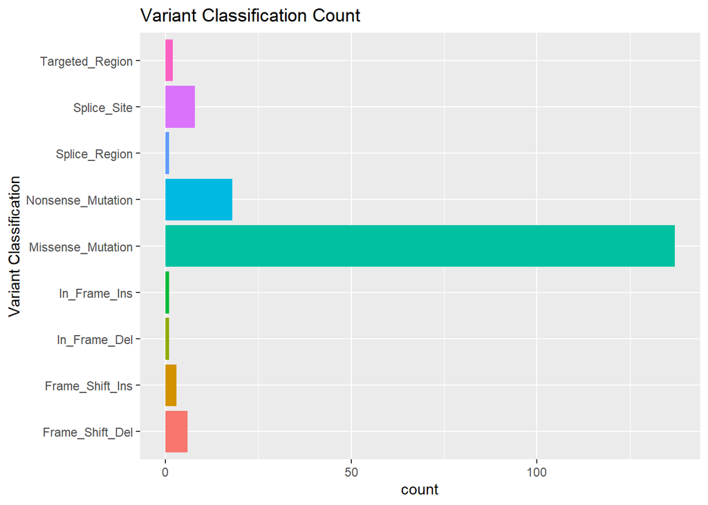

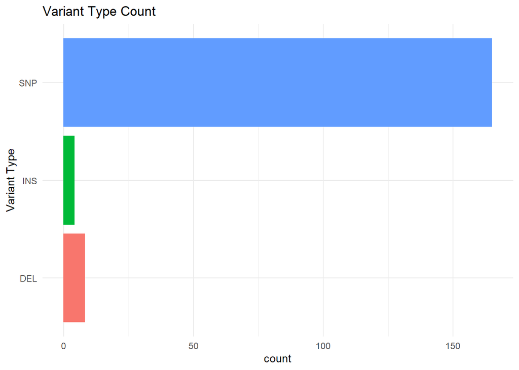

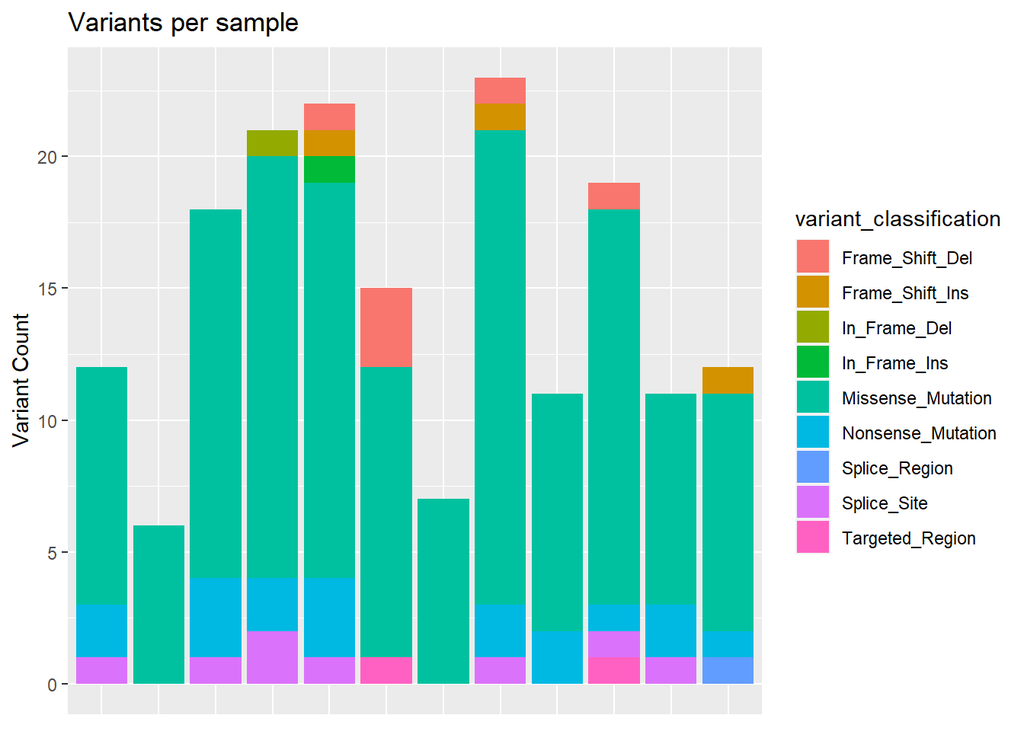

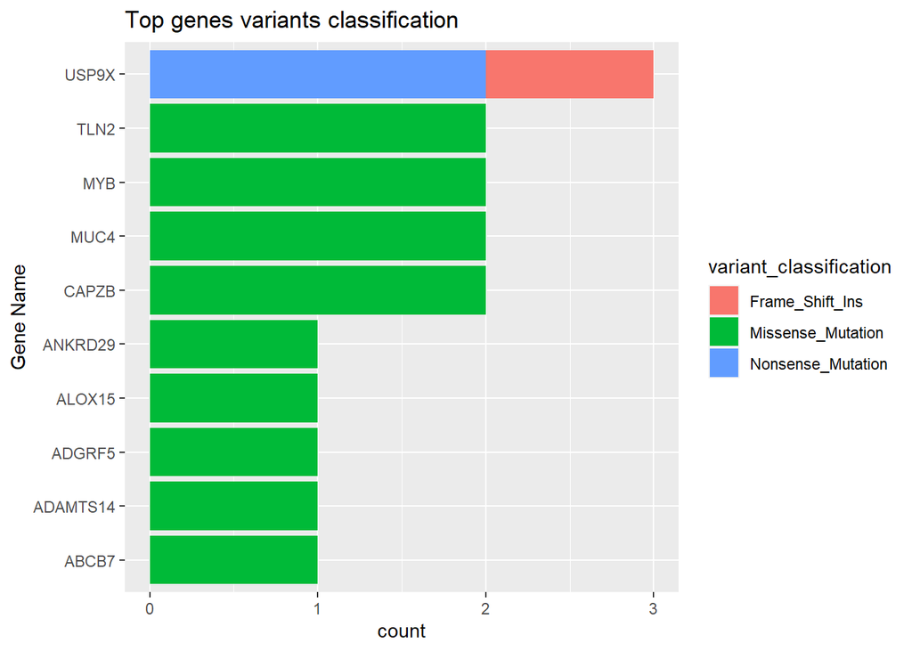

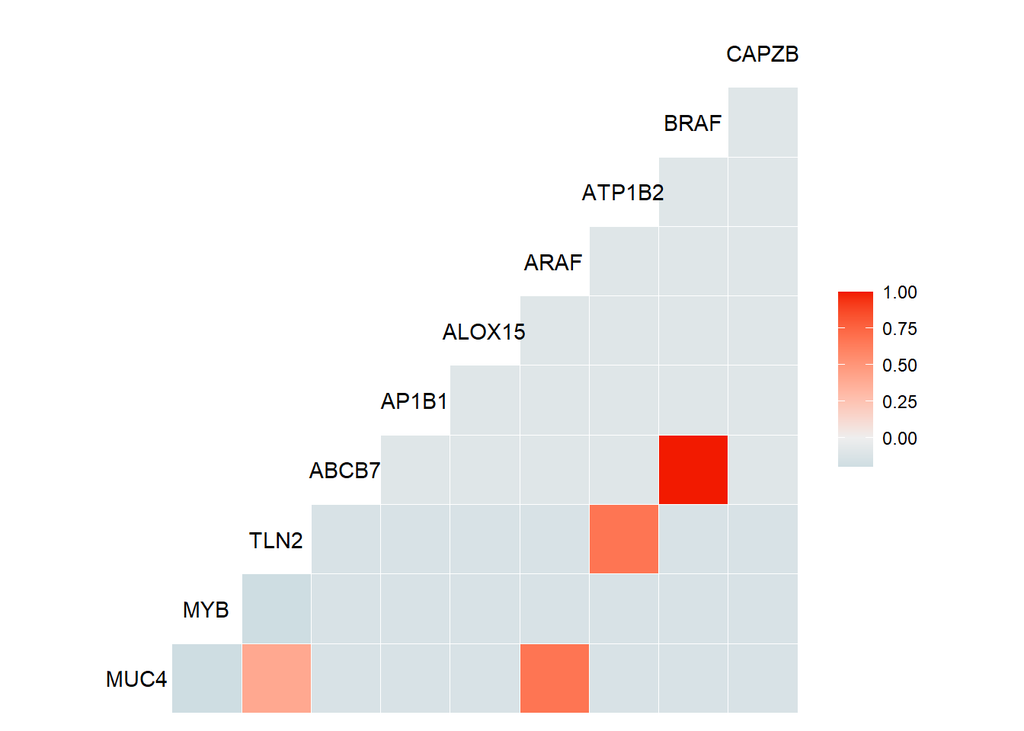

```r
mutation_viz(study_mutation)
```